# Practica1

José Daniel Cuevas Villicaña

2023-08-14

Práctica 1

Para esta práctica, utiliza los datos de la tabla wage1.

1. ¿Qué mide la variable wage?

Dólares ganados por hora

2. ¿Qué mide la variable educ?

Años de estudios

3. ¿Cómo se obtuvieron estos datos?

De una encuesta realizada por el Departamento de Economía de la Universidad de California en Berkeley en 1976

4. ¿Cuántas observaciones tiene esta muestra?

526

5. Calcula la media de la variable wage.

```
## [1] 5.896103
```

6. Calcula la media de la variable educ. ¿Qué significa?

```
## [1] 12.56274
```

7. Calcula los máximos y mínimos de las observaciones para las variables.

```
## [1] 24.98
```

```
## [1] 0.53
```

```
## [1] 18
```

```
## [1] 0
```

$X_{i}=educ$

$Y_{i}=wage$

8. Realiza una tabla con $X_{i}$, $Y_{i}$, $x_{i}$, $y_{i}$, $\hat{y}_{i}$, $\hat{u}_{i}$, $\hat{u}^2_{i}$.

```
##      X     Y           x           y            xy         x^2   Ygorrito
## 1   11  3.10  -1.5627376 -2.79610277   4.369575051   2.4421489  5.0501002
## 2   12  3.24  -0.5627376 -2.65610266   1.494688952   0.3166737  5.5914594
## 3   11  3.00  -1.5627376 -2.89610267   4.525848667   2.4421489  5.0501002
## 4    8  6.00  -4.5627376  0.10389733  -0.474056237  20.8185748  3.4260224
## 5   12  5.30  -0.5627376 -0.59610248   0.335449306   0.3166737  5.5914594
## 6   16  8.75   3.4372624  2.85389733   9.809593848  11.8147725  7.7568965
## 7   18 11.25   5.4372624  5.35389733  29.110544392  29.5638219  8.8396150
## 8   12  5.00  -0.5627376 -0.89610267   0.504270707   0.3166737  5.5914594
## 9   12  3.60  -0.5627376 -2.29610277   1.292103460   0.3166737  5.5914594
## 10  17 18.18   4.4372624 12.28389764  54.506876579  19.6892972  8.2982557
## 11  16  6.25   3.4372624  0.35389733   1.216437955  11.8147725  7.7568965
## 12  13  8.13   0.4372624  2.23389744   0.976799261   0.1911984  6.1328187
## 13  12  8.77  -0.5627376  2.87389778  -1.617250464   0.3166737  5.5914594
## 14  12  5.50  -0.5627376 -0.39610267   0.222901885   0.3166737  5.5914594
```

[output cut: 1039 more lines]

9. Realiza un diagrama de dispersión de los datos, con wage como variable dependiente y educ como variable independiente.

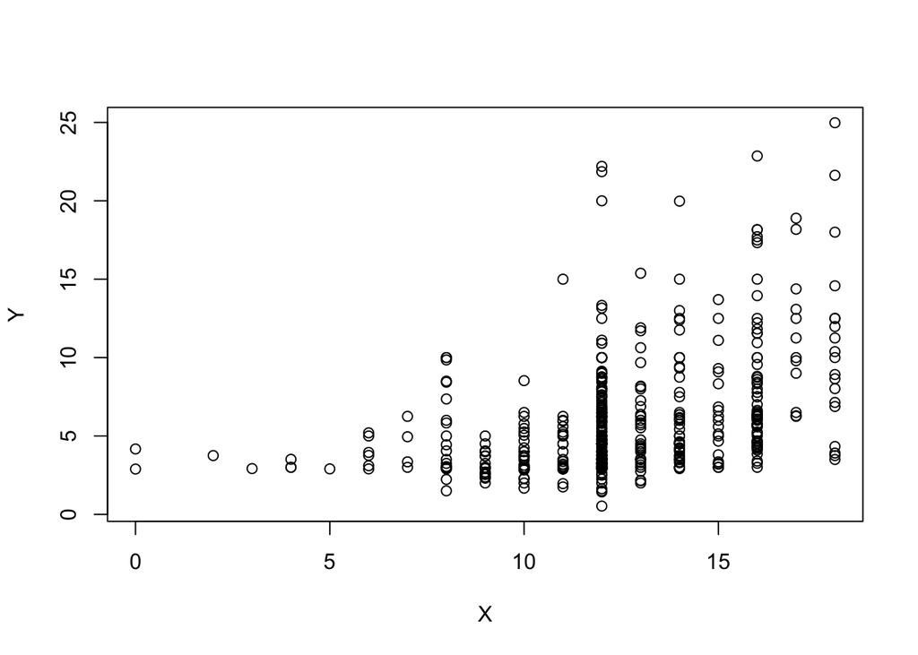

10. Considera un modelo lineal $wage_{i} =\alpha +\beta educ_{i} + u_{i}$ Calcula los estimadores ˆα, βˆ con el método de mínimos cuadrados, de dos maneras distintas:
1. Utiliza las fórmulas vistas en clase.

```
## [1] -0.9048516
```

```
## [1] 0.5413593
```

2. Utiliza el resumen que entrega R.

```
##
## Call:
## lm(formula = Y ~ X, data = tabla2)
##
## Residuals:
##     Min      1Q  Median      3Q     Max
## -5.3396 -2.1501 -0.9674  1.1921 16.6085
##
## Coefficients:
##             Estimate Std. Error t value Pr(>|t|)
## (Intercept) -0.90485    0.68497  -1.321    0.187
## X            0.54136    0.05325  10.167   <2e-16 ***
## ---
## Signif. codes:  0 '***' 0.001 '**' 0.01 '*' 0.05 '.' 0.1 ' ' 1
##
## Residual standard error: 3.378 on 524 degrees of freedom
## Multiple R-squared:  0.1648, Adjusted R-squared:  0.1632
## F-statistic: 103.4 on 1 and 524 DF,  p-value: < 2.2e-16
```

11. Vuelve a realizar diagrama de dispersión de los datos, con wage como variable dependiente y educ como variable independiente. Esta vez, grafica la línea del modelo sobre el diagrama

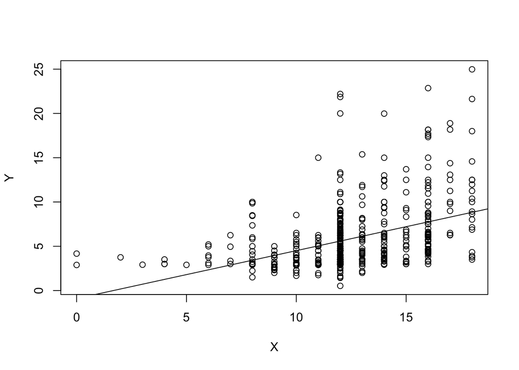

12. Verifica si $\sum^n_{i=1}\hat{u}_{i}\approx 0$

```
## [1] -3.304024e-13
```

13. Verifica si $\sum^n_{i=1}X_{i}\hat{u}_{i}\approx 0$

```
## [1] -3.922196e-12
```

Segunda parte

Considera los mismos datos que en la primera parte, con $Y_{i} = wage_{i}$ , $X_{i} = educ_{i}$

2. Qué significado tiene el parémetro estimado $\hat{\beta}$.

Nos dice cúanto aumenta Y, por cada unidad que aumenta X. En este caso, el sueldo aumenta en 0.5413593 por cada año de educación.

3. De acuerdo a este modelo lineal, ¿cuánto predice que será el sueldo (wage), en promedio, para una persona con 10 años de educación?

```
## [1] 4.508741
```

4. De acuerdo a este modelo lineal, ¿cuánto predice que será el sueldo (wage), en promedio, para una persona con 16 años de educación?

```
## [1] 7.756896
```

5. De acuerdo a este modelo lineal, ¿cuánto predice que aumentará el sueldo (wage), en promedio, si una persona aumenta 1 año de educación?

```
## [1] 0.5413593
```

6. De acuerdo a este modelo lineal, ¿cuánto predice que aumentará el sueldo (wage) si una persona aumenta 4 años de educación?

```
## [1] 2.165437
```

7. Calcula $\sum\limits_{i=1}^n y_{i}^2$

```
## [1] 7160.414
```

8. Calcula $\sum\limits_{i=1}^n\hat{y}_{i}^2$

```
## [1] 1179.732
```

9. Calcula $\sum\limits_{i=1}^n\hat{u}^2_{i}$

```
## [1] 5980.682
```

10. Comprueba que $SCT = SCE + SCR$.

```
## [1] 7160.414
```

```
## [1] 7160.414
```

11. Calcula el coeficiente de determinación R2 de tres maneras:
1. $R^2=SCE/SCT$

```
## [1] 0.1647575
```

2. $R^2=\frac{(\sum\limits_{i=1}^n x_{i}y_{i})^2}{\sum\limits_{i=1}^n x_{i}^2\sum\limits_{i=1}^n y_{i}^2}$

```
## [1] 0.1647575
```

3. Solicitando al software R que lo calcule, como parte de las estimaciones de los parámetros del modelo de regresión lineal. Comprueba que es el mismo resultado en los tres casos.

```
##
## Call:
## lm(formula = Y ~ X, data = tabla2)
##
## Residuals:
##     Min      1Q  Median      3Q     Max
## -5.3396 -2.1501 -0.9674  1.1921 16.6085
##
## Coefficients:
##             Estimate Std. Error t value Pr(>|t|)
## (Intercept) -0.90485    0.68497  -1.321    0.187
## X            0.54136    0.05325  10.167   <2e-16 ***
## ---
## Signif. codes:  0 '***' 0.001 '**' 0.01 '*' 0.05 '.' 0.1 ' ' 1
##
## Residual standard error: 3.378 on 524 degrees of freedom
## Multiple R-squared:  0.1648, Adjusted R-squared:  0.1632
## F-statistic: 103.4 on 1 and 524 DF,  p-value: < 2.2e-16
```

12. Da una interpretación del coeficiente de determinación.

El coeficiente de determinación es una medida que indica qué tan bien se ajusta un modelo de regresión a un conjunto de datos. Se representa por R2 y se calcula como la proporción de la varianza de la variable dependiente que es explicada por el modelo. Su valor está entre 0 y 1, siendo 1 el mejor ajuste posible y 0 el peor.

13. Calcula $\hat{\sigma}^2$

```
## [1] 11.41352
```

14. Calcula $var(\hat{\beta})$

```
## [1] 0.002835353
```

15. Calcula el error estándar $e.e.(\hat{\beta})$

```
## [1] 0.05324804
```

16. Calcula $var(\hat{\alpha})$

```
## [1] 0.4691809
```

17. Calcula e.e(ˆα)

```
## [1] 0.6849678
```

18. Compara el error estándar calculado con las estimaciones dadas por R en el resumen (summary) de estimadores del modelo lineal.

```
##
## Call:
## lm(formula = Y ~ X, data = tabla2)
##
## Residuals:
##     Min      1Q  Median      3Q     Max
## -5.3396 -2.1501 -0.9674  1.1921 16.6085
##
## Coefficients:
##             Estimate Std. Error t value Pr(>|t|)
## (Intercept) -0.90485    0.68497  -1.321    0.187
## X            0.54136    0.05325  10.167   <2e-16 ***
## ---
## Signif. codes:  0 '***' 0.001 '**' 0.01 '*' 0.05 '.' 0.1 ' ' 1
##
## Residual standard error: 3.378 on 524 degrees of freedom
## Multiple R-squared:  0.1648, Adjusted R-squared:  0.1632
## F-statistic: 103.4 on 1 and 524 DF,  p-value: < 2.2e-16
```

19. La covarianza entre $\hat{\beta}$ y $\hat{\alpha}$ está dada por $cov(\hat{\alpha},\hat{\beta})=-\overline{X}var(\hat{\beta})$ Calcula $cov(\hat{\alpha},\hat{\beta})$

```
## [1] -0.0356198
```